# Intern Project - Framework, Proposal and Ongoing Works

Lu Chen  
Jun 15 2023

## Task List

[ ] **Stage One: Conceptual Framework** TIMELINE

- Work flow framework
  - work flow template
  - conceptual framework
  - technical workflow framework
    - ask ds feedback
    - summarize technical questions
- Learn Urban metrics
- Make a task list

[ ] **Stage Two: Finetune Modeling and Analysis Results**

[ ] **Stage Three: Demo Work in Urban**

## Feedback

### From Michelle 06/20

- !!! Workflow of creating metrics
- Explore what can and can't Urban do? a test to Urban's limitation and offer feedback.
- First concepturalize what approach could be
  - Then, define what is feasible in this internship?
- **priority**: framework and workflow, task list
  - ask for work flow template
  - summarize my modeling todo list and questions
  - reach out to ds about modeling: Eliza mentioned, Michelle mentioned

## Introduction

The COVID-19 pandemic has provided a unique window to study the profound influence of human behavior on urban energy consumption, transportation, and other facets of urban life. Forced by the global health crisis and the consequential policies, such as lockdowns, society has embraced unprecedented lifestyle shifts, most notably remote work. During this period, we witnessed a mass exodus from densely populated metropolitan areas, and intriguingly, some individuals opted to remain in less dense areas even post-pandemic. This global event has inadvertently orchestrated a large-scale experiment, dividing our lives into pre-pandemic, pandemic, and post-pandemic phases. Despite the tragedy of the disease, it is crucial that we seize this opportunity to understand how diverse societal groups have adapted to the pandemic and how their behavioral changes have reshaped urban spaces and environments. In an attempt to quantify these shifts, I aim to utilize mobility and energy consumption data.

## Research Question

1. What is the worldwide trend of working from home (WFH) during and post the COVID-19 pandemic, and what factors might account for the observed variations?
2. How has building energy consumption responded to the pandemic, and what variables might explain the differences in changes across various regions or types of buildings?
3. **Work flow leverage ArcGIS and Urban to analyze and predict WFH percentage and energy consumption change related to it.**

## My thoughts about this part for intern project

- [o] I think this part could be great as a overview. It would be fun if I put WFH related data as metrics in the urban model and visualize the analysis results.
- [o] Theoratically, with analysis and data we can predict the percent of WFH population based on demographic and land use info of a plan.
- [o] Based on correlation analysis on WFH, demographic, structual and space use factors and energy consumption, we could predict energy consumption changes in Urban.
- [o] And with customized space use metrics in Urban, users could easily adjust weights and compare WFH/energy consumption in different planning scenerio.
- [?] My model was simple, if we decided to use this eventually, I need to improve it and compare different groups and districts.
- [?] To do: Learn how to put land use info in Urban model and manipulate other metrics and maybe create new WFH related metrics.

## Data Source

### 1. WFH population and socio-economic characteristics

#### **American Community Survey (ACS) 2021 (5-Year Estimates)**

- Source: https://www.socialexplorer.com/data/ACS2021_5y
- Data geographical coverage: Nationwide
- Description: The data shows WFH population in 2021 survey, and depict factors such as education level, income, occupation and so on.

### 2. Detailed daily mobility data during pandemic

#### **Google's Covid-19 Community Mobility Report**

- Source: https://www.google.com/covid19/mobility/
- Time range: 2020-02-15 to 2022-10-15
- Data geographical coverage: Global
- Description: The data shows movement trends over time by geography, across different categories of places such as retail and recreation, groceries and pharmacies, parks, transit stations, workplaces, and residential.
  - It shows how visitors to (or time spent in) categorized places change compared to our baseline days. A baseline day represents a normal value for that day of the week. The baseline day is the median value from the 5‑week period Jan 3 – Feb 6, 2020.
  - For each region-category, the baseline isn’t a single value—it’s 7 individual values. The same number of visitors on 2 different days of the week, result in different percentage changes.

### 3. Building Energy Consumption and Energy Related Building Characteristics

#### **Energy and Water Data Disclosure for Local Law 84**

- Source: https://data.cityofnewyork.us/Environment/Energy-and-Water-Data-Disclosure-for-Local-Law-84-/7x5e-2fxh
- Time range: monthly data 2018 - 2020; yearly data 2013 - 2021
- Data geographical coverage: New York City
- Description: The data collection requires building owners to measure their energy and water consumption and compare it against that of similar buildings in the city and country.
  - Data and metrics on water and energy consumption in privately owned buildings over 25,000 ft2 and in City-owned buildings over 10,000 ft2.
  - Please visit https://www1.nyc.gov/site/buildings/codes/benchmarking.page for additional information.

### 4. Detailed Building Information

#### **National Structure Inventory (NSI) Database**

- Source: https://www.hec.usace.army.mil/confluence/nsi/technicalreferences/latest/technical-documentation
- Time range: 2019, 2020
- Data geographical coverage: Nationwide
- Description: very detailed structural data and building activity information.

### 5. Tax lot infomation and land use data

#### **Primary Land Use Tax Lot Output (PLUTO) Database**

- Source: https://data.cityofnewyork.us/City-Government/Primary-Land-Use-Tax-Lot-Output-PLUTO-/64uk-42ks
- Data geographical coverage: New York City

## Nationwide Trend of WFH

### Variables

- Dependent Variable: WFH rate *This variable was derived from "Means of Transportation to Work for Workers 16 Years and Over" data.*
- Explanatory Variables: These variables were selected because they are anticipated to have a substantial effect on the WFH trend.
  - Population: The total county population was utilized as a measurement of county size.
  - High education level: The percentage of the population with a Bachelor's degree or higher.
  - High household Income: The percentage of households with incomes exceeding $200,000.
  - Occupation: the percentage of the population employed in three industries with a higher likelihood of WFH and three industries with a lower likelihood of WFH based on experience.
    - High likelihood industries: "Information", "Finance and Insurance, and Real Estate and Rental and Leasing", and "Professional, Scientific, and Management, and Administrative and Waste Management Services".
    - Low likelihood industries: "Construction", "Manufacturing" and "Retail Trade".

### Maps of WFH population and other factors

[figure not shown]

### Correlationship between WFH and socio-economic factors

**Multiple Regression Model** | Variables | Coefficient | Standard Error | T-value | P-value | |-----------------------------------|-------------|----------------|---------|---------| | Total Population | 0.00 | 0.00 | -1.21 | 0.23 | | % Household Income higher than 200k | -0.14 | 0.07 | -1.85 | 0.07 | | Manufacturing | -0.04 | 0.06 | -0.69 | 0.49 | | % population work in Retail Trade | -0.75 | 0.38 | -1.97 | 0.05 | | % population work in Information | 0.91 | 0.38 | 2.40 | 0.02 | | % population work in Finance | 0.03 | 0.15 | 0.22 | 0.83 | | % population work in Professional and Scientific | 0.20 | 0.17 | 1.17 | 0.25 | | Intercept | -2.24 | 3.61 | -0.62 | 0.54 |

### Try vis it with Urban and StoryMaps? Put wfh indicators in Urban model? Put plan in urban?

## Change of Mobility in Different Areas in NYC

### Descriptive Stats and Overview

**TODO: Analysis on the change pattern of mobility in different types of spaces**

```python
import pandas as pd
import numpy as np
import matplotlib.pyplot as plt

def print_df_info(df):
    """
    Prints the shape of the DataFrame and its first few rows.
    """
    print("Data shape:", df.shape)
    print("Data head:")
    print(df.head())

# load data
nyc_mobility = pd.read_csv('/Users/luchen/Documents/MSUA/2023Spring/Capstone/datasets/Google Mobility Data/nyc_mobility.csv', na_values='')
# print_df_info(nyc_mobility)
```

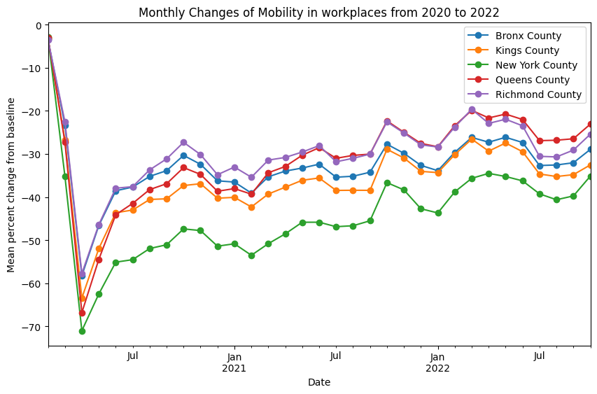

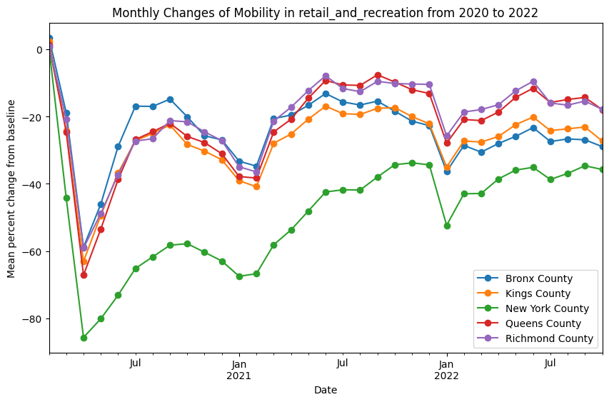

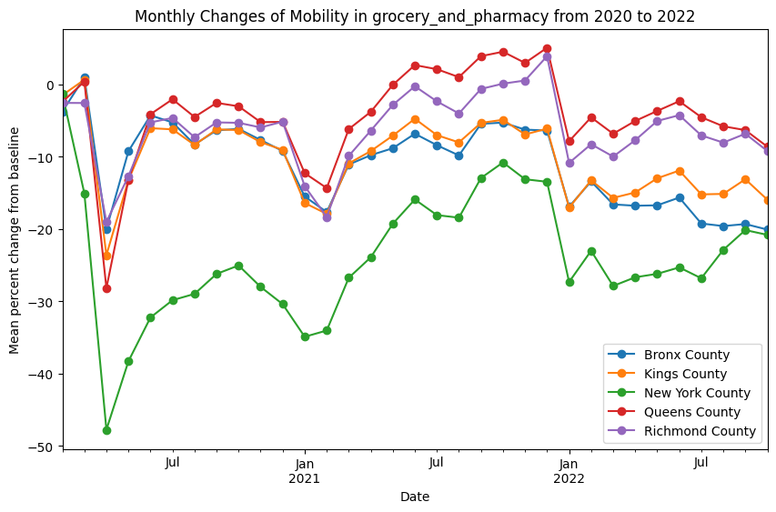

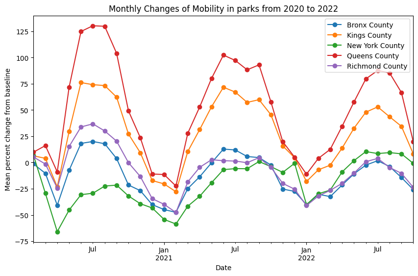

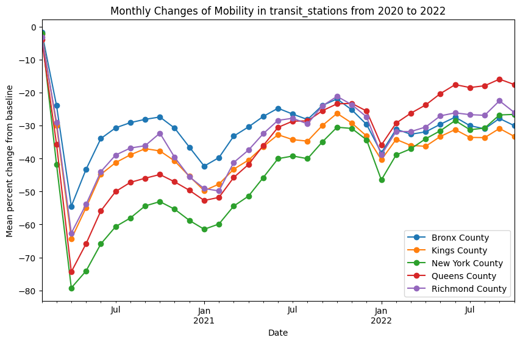

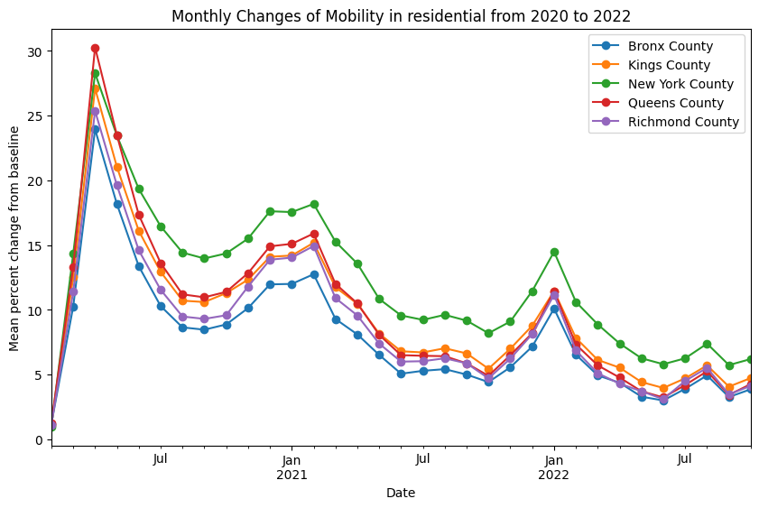

```python
# Monthly Changes of mobility from 2020 to 2022'
def show_mobility_for_place(nyc_mobility, place):
    # Convert 'year' and 'month' columns to datetime
    nyc_mobility['y-m date'] = pd.to_datetime(nyc_mobility['year'].astype(str) + '-' + nyc_mobility['month'].astype(str), format='%Y-%m')
    nyc_mobility.sort_values('y-m date', inplace=True)

    # Group the NYC mobility data by 'sub_region_2' and 'date' and calculate the mean value
    grouped_data = nyc_mobility.groupby(['sub_region_2', 'y-m date'])[place + '_percent_change_from_baseline'].mean().reset_index()

    # Pivot the data to have 'sub_region_2' as columns and 'date' as rows
    pivot_data = grouped_data.pivot(index='y-m date', columns='sub_region_2', values=place + '_percent_change_from_baseline')

    # Plotting the line chart
    pivot_data.plot(kind='line', marker='o', figsize=(10, 6))
    # Set the chart title and labels
    plt.title('Monthly Changes of Mobility in ' + place + ' from 2020 to 2022')
    plt.xlabel('Date')
    plt.ylabel('Mean percent change from baseline')

    # Show the legend
    plt.legend()

    # Display the line chart
    plt.show()

show_mobility_for_place(nyc_mobility, 'workplaces')
show_mobility_for_place(nyc_mobility, 'retail_and_recreation')
show_mobility_for_place(nyc_mobility, 'grocery_and_pharmacy')
show_mobility_for_place(nyc_mobility, 'parks')
show_mobility_for_place(nyc_mobility, 'transit_stations')
show_mobility_for_place(nyc_mobility, 'residential')
```

## Correlation between All those Factors

Maybe a Multi OLS model TODO

## Urban Model with WFH and energy Metrics

Can I put above results in Urban metrics to better discribe and visualize the city Use above indicators and numbers for future project and predict stuff